# baselines_Bonn

### Calculation of the Baseline Energy Consumption of the SmartHabits Pilot #2

```python
%matplotlib inline
```

```python
import numpy as np
import pandas as pd
from statsmodels import api as sm
from statsmodels.stats.stattools import durbin_watson
import datetime
import patsy

from matplotlib import pyplot as plt
plt.rcParams['figure.dpi'] = 300
plt.rcParams['savefig.dpi'] = 300

import seaborn as sns
sns.set_style("ticks")
```

Read the energy consumption data (heat and electricity).

```python
data = pd.read_csv("Bonn_energy.csv", sep=',', index_col=0, na_values="0",
                   date_parser=lambda s: datetime.datetime.strptime(s, "%m/%d/%Y %H:%M").date())

data = data.apply(pd.Series.interpolate)

heat = data['Heating (kWh)'].dropna()
power = data['Electricity (kWh)'].dropna()
```

First, focus on **heat consumption**.

```python
print('The mean daily heat consumption is %d kWh' %heat.mean())
annual_sum = heat.sum()*365/len(heat)
print('The total heat consumption per annum is %d kWh' %annual_sum)
```

```
The mean daily heat consumption is 1289 kWh
The total heat consumption per annum is 470526 kWh
```

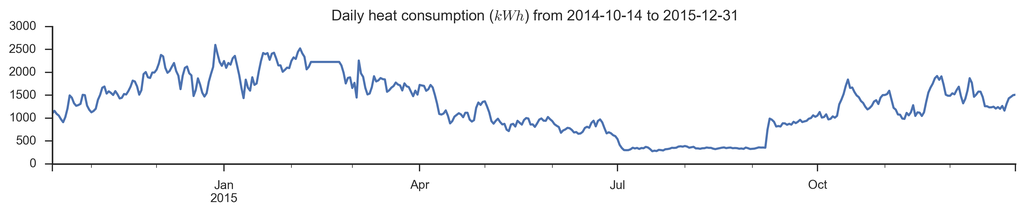

```python
fig, ax = plt.subplots(figsize=(14,2))

title = 'Daily heat consumption ($kWh$) from %s to %s' %(heat.index[0].date(), heat.index[-1].date())

heat.plot(ax=ax, kind='line', title=title)
sns.despine(right=True);
```

Is there a "day of week" effect?

```python
day_of_week = {0: 'Monday', 1: 'Tuesday', 2: 'Wednesday', 3: 'Thursday', 4: 'Friday', 5: 'Saturday', 6: 'Sunday'}

data['weekday'] = data.index.map(lambda d: day_of_week[d.weekday()])
```

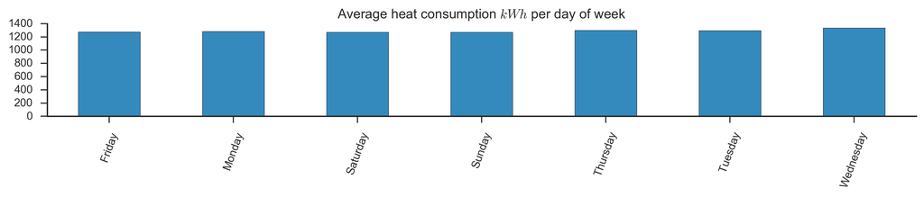

```python
grouped = pd.concat([data['weekday'].ix[heat.index], heat], axis=1).groupby('weekday').apply(np.mean)

fig, ax = plt.subplots(figsize=(14,1.5))

grouped.plot(ax=ax, kind='bar', color="#348ABD", title='Average heat consumption $kWh$ per day of week')
ax.legend_.remove()
plt.xlabel('')
plt.setp(ax.xaxis.get_majorticklabels(), rotation=70)
sns.despine(right=True);
```

The data suggests no "day of week" effect.

Check for the dependency of the heat consumption on the ambient weather temperature.

Load the corresponding temperature data. The data originate from the [Weather Underground](http://www.wunderground.com/history) service.

```python
weather_2014 = pd.read_csv("Bonn_weather_2014.csv", sep=',', index_col=0,
                             date_parser=lambda s: datetime.datetime.strptime(s, "%Y-%m-%d").date())

temperature = weather_2014['Min TemperatureC']

weather_2015 = pd.read_csv("Bonn_weather_2015.csv", sep=',', index_col=0,
                             date_parser=lambda s: datetime.datetime.strptime(s, "%Y-%m-%d").date())

temperature = pd.concat([temperature, weather_2015['Min TemperatureC']])

temperature = temperature.ix[heat.index]
```

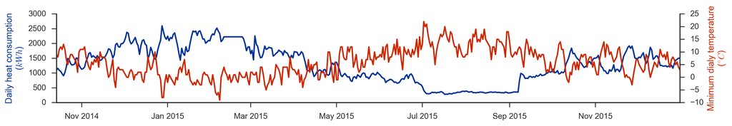

```python
fig, ax1 = plt.subplots(figsize=(14,2))

ax2 = ax1.twinx()
ax1.plot(heat.index, heat, color="#003399")
ax2.plot(heat.index, temperature, color="#cc2900")

ax1.set_ylabel('Daily heat consumption\n($kWh$)', color="#003399")
ax2.set_ylabel('Minimum dialy temperature\n($^{\circ}C$)', color="#cc2900")
sns.despine(right=False);
```

We will fit a penalized spline on the temperature-heat consumption relationship.

Define a function that fits the spline given the target data `y`, the basis matrix `B`, the degrees of freedom `df` and the smoothing/regularization parameter $\lambda$.

```python
def spline_fit(y, B, df, lambda_=1.0):
    # build difference matrix
    P = np.diff(np.diag(np.ones(df)), n=1, axis=1)
    D = np.dot(P, P.T)
    # build the augmented matrices
    if(y.ndim ==1):
        y_ = np.vstack((np.expand_dims(y, axis=1), np.zeros((df, 1))))

    else:
        y_ = np.vstack((y, np.zeros((df, 1))))
    X_ = np.vstack((B, np.sqrt(lambda_) * D))

    return sm.OLS(y_, X_).fit()
```

Next, we define the [generalized cross-validation](http://www.stat.wisc.edu/~wahba/ftp1/oldie/golub.heath.wahba.pdf) score to choose the optimal value of $\lambda$. The GCV score is given by

$\operatorname{GCV}(\lambda) = \frac{n \sum_{i = 1}^n \left(y_i - \hat{y}_i\right)^2}{\left(n - \operatorname{tr} \mathbf{H}\right)^2}.$

Here, $\hat{y}_i$ is the $i$-th predicted value, and $\mathbf{H}$ is upper left $n \times n$ submatrix of the the influence matrix for the OLS model $\mathbf{\tilde{y}} = \mathbf{\tilde{X}} + \varepsilon$.

```python
def gcv_score(results, df):
    X = results.model.exog[:-df, :]
    n = X.shape[0]
    y = results.model.endog[:n]

    y_hat = results.predict(X)
    hat_matrix_trace = results.get_influence().hat_matrix_diag[:n].sum()

    return n * np.power(y - y_hat, 2).sum() / np.power(n - hat_matrix_trace, 2)
```

Finally, we define a function to combine spline fitting and cross-validation.

```python
def qspline(y, x, df, hasconst=True):

    if hasconst:
        basis_matrix = patsy.dmatrix('1 + bs(x, df)', {"x": x, "df": df})
        df += 1
    else:
        basis_matrix = patsy.dmatrix('bs(x, df) - 1', {"x": x, "df": df})

    lambdas = np.logspace(0, 50, 100, base=1.5) * 1e-8
    gcv_scores = np.array([gcv_score(spline_fit(y, basis_matrix, df, lambda_=lambda_), df) for lambda_ in lambdas])
    lambda_best = lambdas[gcv_scores.argmin()]
    results = spline_fit(y, basis_matrix, df, lambda_=lambda_best)
    return results, basis_matrix
```

Find the relationship between temperature and heat consumption.

```python
results, basis_matrix = qspline(heat, temperature, 4)
```

```python
spline_temperature = results.predict(patsy.build_design_matrices([basis_matrix.design_info], {'x': temperature})[0])
```

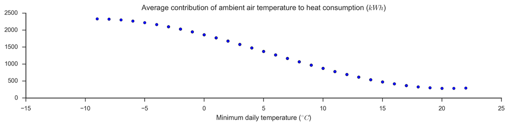

```python
fig, ax = plt.subplots(figsize=(14,2.5))

ax.scatter(temperature, spline_temperature)

ax.set_xlabel('Minimum daily temperature ($^{\circ}C$)')
ax.set_title('Average contribution of ambient air temperature to heat consumption ($kWh$)')
sns.despine(right=True);
```

How good is the in-sample fit?

Plot the residuals.

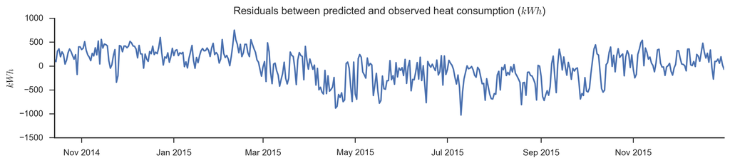

```python
fig, ax = plt.subplots(figsize=(14,2.5))

resid = heat - spline_temperature

ax.plot(heat.index, resid)
ax.set_title('Residuals between predicted and observed heat consumption ($kWh$)')
ax.set_ylabel('$kWh$')

sns.despine(right=True);
```

It seems that there is a time-dependent pattern in the residuals.

Let's examine the 45-day rolling mean of the residuals.

```python
ndays = 45
rolling_mean = pd.rolling_mean(resid, ndays, center=True)
```

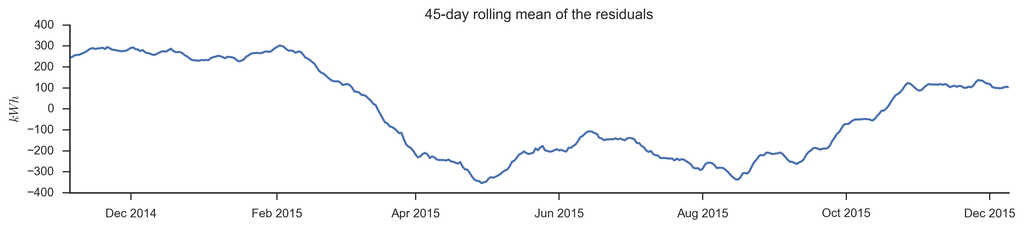

```python
fig, ax = plt.subplots(figsize=(14,2.5))

ax.plot(heat.index, rolling_mean)
ax.set_title('%d-day rolling mean of the residuals' %ndays)
ax.set_ylabel('$kWh$')

sns.despine(right=True);
```

Since this pattern is after we have accounted for ambient temperature variation, we can hypothesize that it is caused by a residents starting their vaciations as summer approaches (a "time of year" effect).

We can fit a second spline that captures this yearly cycle, through a backfitting procedure.

```python
def backfit():

    rsquared = 0
    spline_time = 0
    spline_temperature = 0
    t = range(len(heat))

    for _ in range(100):

        resid = heat - spline_time
        results, basis_matrix = qspline(resid, temperature, 4)
        spline_temperature = results.predict(patsy.build_design_matrices([basis_matrix.design_info],
                                                                                      {'x': temperature})[0])

        if(abs(results.rsquared - rsquared) < 0.0001):
            print('Loop finished because R-squared stopped improving')
            break
        else:
            rsquared = results.rsquared
            resid = heat - spline_temperature
            results, basis_matrix = qspline(resid, t, 4, hasconst=False)
            spline_time = results.predict(patsy.build_design_matrices([basis_matrix.design_info], {'x': t})[0])

    return spline_temperature, spline_time, results
```

```python
spline_temperature, spline_time, results = backfit()
```

```
Loop finished because R-squared stopped improving
```

Plot the two splines.

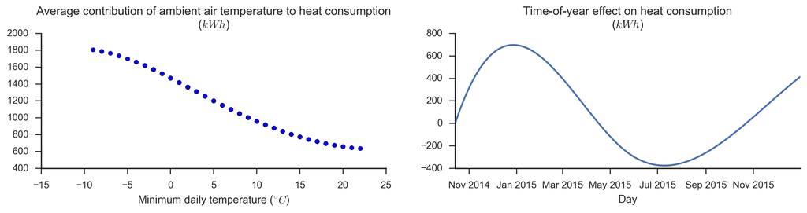

```python
fig, axes = plt.subplots(nrows=1, ncols=2, squeeze=True, figsize=(14, 2.5))

axes[0].scatter(temperature, spline_temperature)
axes[0].set_xlabel('Minimum daily temperature ($^{\circ}C$)')
axes[0].set_title('Average contribution of ambient air temperature to heat consumption\n($kWh$)')

axes[1].plot(heat.index, spline_time)
axes[1].set_xlabel('Day')
axes[1].set_title('Time-of-year effect on heat consumption\n($kWh$)')

sns.despine(right=True);
```

Plot the residuals again.

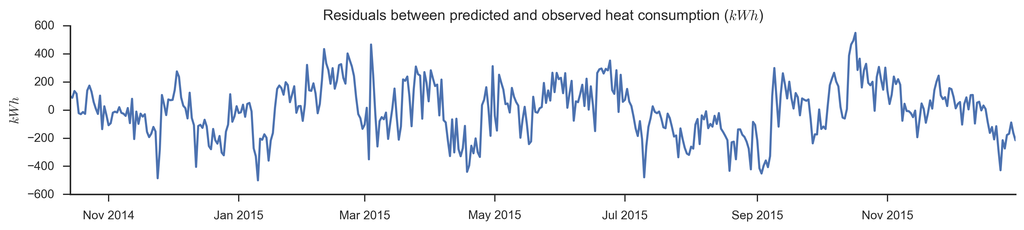

```python
fig, ax = plt.subplots(figsize=(14,2.5))

resid = heat - spline_temperature - spline_time

ax.plot(heat.index, resid)
ax.set_title('Residuals between predicted and observed heat consumption ($kWh$)')
ax.set_ylabel('$kWh$')

sns.despine(right=True);
```

A first observation is that even when accounting for temperature and time-of-year effects, heat consumption **is characterized by significantly higher variance** than electrcity consumption. This means that focusing on heat consumption practices may lead us to discover greater energy saving opportunities.

```python
heat_rolling_std = pd.rolling_std(resid, ndays, center=True)
power_rolling_std = pd.rolling_std(power.ix[heat.index], ndays, center=True)
```

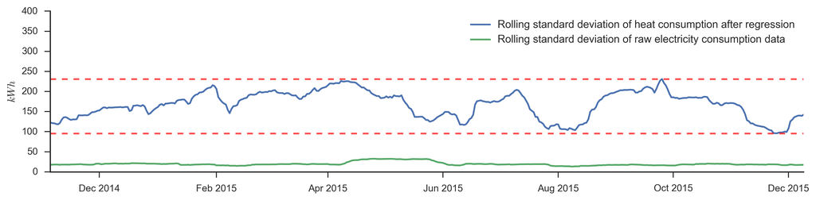

```python
fig, ax = plt.subplots(figsize=(14, 3))

ax.plot(heat.index, heat_rolling_std, label='Rolling standard deviation of heat consumption after regression')
ax.plot(heat.index, power_rolling_std, label='Rolling standard deviation of raw electricity consumption data')
ax.set_ylabel('$kWh$')
ax.axhline(y=heat_rolling_std.min(), ls='dashed', alpha=0.7, color='red')
ax.axhline(y=heat_rolling_std.max(), ls='dashed', alpha=0.7, color='red')

plt.ylim(0, 400)
legend = ax.legend(loc='upper right')
plt.setp(legend.get_texts(), fontsize='11')
sns.despine(right=True);
```

The range is:

```python
'%d kWh per day' %(heat_rolling_std.max() - heat_rolling_std.min())
```

```
135 kWh per day
```

When interpreting the plot above, one must keep in mind that any succesful model is able to explain away some of the variance in the data. While heat consumption is depicted after applying the model for temperature and time-of-year effects, the electricity consumption is depicted as is, i.e. before any part of its variance is eliminated using day-of-week or time-of-year variables.

A second observation is that the residuals exhibit positive autocorrelation:

```python
'It is ' + '{0:.2f}'.format(durbin_watson(resid)) + ', when 0 corresponds to perfect positive correlation'
```

```
It is 0.57, when 0 corresponds to perfect positive correlation
```

This means that we cannot use the confidence intervals from the regression model. We could whiten the data by removing the estimated autocorrelation: $(2 - durbin\_watson\_statistic) /2$. However, since temperature and time-of-year are also autocorrelated, both temperature and time-of-year will be overshadowed by the predictive power of the lagged variable.

Instead, we will focus on achieving the following:

**1. Reducing the variance of the heat consumption**. Succesful rules on more efficient use of heating/cooling equipment should be able to reduce the (local) variance of heat consumption under similar conditions of ambient air temperature and time of year. When examined locally (i.e., during a short time window), people living in the pilot building have a very regular occupancy pattern; this supports the argument of judging the performace of the derived rules by their ability to lower variation.

**2. Challenging setpoint preferences/habits**. Affecting setpoint preferences means affecting the curve that represents the average contribution of ambient air temperature to heat consumption. After the end of the pilot, we can follow the same approach as the one presented here, so as to derive the new curve, and assess the corresponding energy savings by applying the same temperature time-series on both spline models.

```python
import warnings
warnings.simplefilter(action = "ignore", category = [UserWarning, FutureWarning])
```

```python
from IPython.core.display import HTML


def css_styling():
    styles = open("styles/custom.css", "r").read()
    return HTML(styles)

css_styling()
```